# Example 22A: Neural Networks for Regression

A neural network is a supervised model inspired by mathematical models of neurons from the 1950s. It comprises interconnected nodes called neurons, arranged in layers. The primary focus of coding a neural network is on these layers, where we specify the number of neurons in each layer. Each neuron can be thought of as an element in a vector, matrix, or higher-order tensor. These values, along with others in the layer, are used to compute the neurons in the next layer using an activation function denoted as $\varphi$, and an affine map. The function can be written as the following: $$y_i = \sum_{i=1}^n \varphi({\bf w}_i \cdot {\bf x} + b_i)$$ where

- $n$ is the number of neurons in the layer,
- ${\bf x}$ is the vector of neuronal values,
- ${\bf w}_i$ are the **weights** or coefficients,
- $b_i$ is the **bias** or intercept, and
- $y_i$ represents the $i^{th}$ neuron in the subsequent layer for which ${\bf w}_i$ and $b_i$ are associated to (each neuron in the subsequent layer will have different weights and biases used to compute it).

Although we generally want to avoid high-variance models, neural networks are the exception. Neural networks are effective tools for handling high-dimensional data with relatively simple patterns. Still, we need to be very cautious about overfitting.

In the example below, our model uses the following hyperparameters:

- **hidden_layer_sizes**: A list of sizes of hidden layers. This variable captures both the sizes and the quantities of the hidden layers.
- **activation_functions**: The list of activation functions used between layers. ReLU (Rectified Linear Unit) and sigmoid activation functions are common to use.
- **optimizer**: The choice of optimization algorithm. In this case, Adam optimizer is used.
- **learning_rate**: The learning rate used by the optimizer (Adam optimizer in this case).
- **num_epochs**: The number of training epochs.
- **batch_size**: The batch size used in mini-batch gradient descent during training.
- **criterion**: The loss function used for training. In this example, Mean Squared Error (MSE) loss is used. Mean absolute error is another popular choice.

```python
# Standard imports
import numpy as np
import matplotlib.pyplot as plt
import seaborn as sns

# Dataset
from sklearn.datasets import load_diabetes, load_iris

# For model and evaluation
import torch
import torch.nn as nn
import torch.optim as optim
from torch.utils.data import DataLoader, TensorDataset
from sklearn.model_selection import train_test_split
from sklearn.preprocessing import StandardScaler
from sklearn.metrics import mean_squared_error, r2_score, classification_report
```

## Neural Networks as Regression

The example below performs regression. We use PyTorch to create this model, which requires the use of object oriented programming (OOP). To make these clsses easier to follow, we include more extensive documentation for the classes and methods.

```python
import torch.nn as nn

class NeuralNetwork(nn.Module):
    """
    A feedforward neural network for regression.

    Args:
        input_size (int): The size of the input features.
        hidden_layer_sizes (list of int): Sizes of hidden layers.
        activation_functions (list of callable): Activation functions for each layer.
        dropout_prob (float): Dropout probability.

    Raises:
        ValueError: If the number of activation functions doesn't match the layer sizes.

    Attributes:
        layers (nn.ModuleList): List of network layers.

    Example:
        To create a neural network with 2 hidden layers using ReLU activation and a dropout
        probability of 0.2:

        >>> network = NeuralNetwork(input_size=64, hidden_layer_sizes=[32, 16],
        ...                         activation_functions=[nn.ReLU, nn.ReLU],
        ...                         dropout_prob=0.2)
    """

    def __init__(self, input_size, hidden_layer_sizes, activation_functions, dropout_prob):
        """
        Initializes the NeuralNetwork.

        Args:
            input_size (int): The size of the input features.
            hidden_layer_sizes (list of int): Sizes of hidden layers.
            activation_functions (list of callable): Activation functions for each layer.
            dropout_prob (float): Dropout probability.

        Raises:
            ValueError: If the number of activation functions doesn't match the layer sizes.
        """

        if len(hidden_layer_sizes) + 2 != len(activation_functions):
            raise ValueError(f"Number of activation functions must be {len(hidden_layer_sizes)+2}.")

        super(NeuralNetwork, self).__init__()
        layers = [input_size] + hidden_layer_sizes + [1]
        self.layers = nn.ModuleList([
            nn.Sequential(
                nn.Linear(layers[i], layers[i+1]),
                activation_functions[i](),
                nn.Dropout(p=dropout_prob)
            )
            for i in range(len(layers) - 1)
        ])

    def forward(self, x):
        """
        Forward pass through the neural network.

        Args:
            x (torch.Tensor): Input data.

        Returns:
            torch.Tensor: Output prediction.
        """
        for layer in self.layers:
            x = layer(x)
        return x
```

PyTorch offers a framework for coding neural networks that is highly flexible. While there are many styles for coding a neural network, we opt for a more modular one, leveraging the natural object-oriented style required. This makes for longer code, but comments and documentation strings are written to help understand what each method does and how to use it.

```python
class NeuralNetworkTrainer:
    """
    A class for training and evaluating neural network models.

    Attributes:
        - activation_functions (list): Activation functions for each layer.
        - batch_size (int): Batch size for training.
        - criterion (torch.nn.Module): Loss function used for training.
        - dropout_prob (float): Dropout probability.
        - hidden_layer_sizes (list): Sizes of hidden layers.
        - learning_rate (float): Learning rate for optimization.
        - model (NeuralNetwork): The neural network model object.
        - num_epochs (int): Number of training epochs.
        - optimizer (torch.optim.Optimizer): Optimizer used for model optimization.
        - train_losses (list): Training set loss values per epoch.
        - train_r2 (list): Training set R^2 values per epoch.
        - val_losses (list): Validation set loss values per epoch.
        - val_r2 (list): Validation set R^2 values per epoch.

    Methods:
        - `__init__(num_epochs=200, hidden_layer_sizes=[64,32], activation_functions=[nn.ReLU, nn.ReLU],
        learning_rate=0.001, batch_size=64, optimizer=optim.Adam, criterion=nn.MSELoss(), dropout_prob=0.1)`:
            Initialize the NeuralNetworkTrainer with hyperparameters and attributes.

        - `train(X_train, y_train, X_val, y_val, printups=False)`:
            Train the neural network model.

        - `suggested_epochs()`:
            Find the suggested number of epochs based on training and validation loss.

        - `validation_mse_graph()`:
            Plot Mean Squared Error (MSE) for training and validation over epochs.

        - `validation_r2_graph()`:
            Plot R-squared for training and validation over epochs.

        - `coefficient_heatmap()`:
            Visualize the neural network weights as heatmaps by layer.

        - `actual_vs_predicted(X_test, y_test)`:
            Plot actual versus predicted values for test data.
    """

    def __init__(self, num_epochs=200, hidden_layer_sizes=[64,32],
                 activation_functions = [nn.ReLU, nn.ReLU] , learning_rate = 0.001,
                 batch_size = 64, optimizer = optim.Adam,
                 criterion = nn.MSELoss(), dropout_prob = 0.1):
        """
        Initialize the NeuralNetworkTrainer with hyperparameters and attributes.

        Args:
            num_epochs (int): Number of training epochs (default is 200).
            hidden_layer_sizes (list): Sizes of hidden layers (default is [64, 32]).
            activation_functions (list): Activation functions for each layer (default is [nn.ReLU, nn.ReLU]).
            learning_rate (float): Learning rate for optimization (default is 0.001).
            batch_size (int): Batch size for training (default is 64).
            optimizer (torch.optim.Optimizer): Optimizer class for model optimization (default is optim.Adam).
            criterion (torch.nn.Module): Loss function for training (default is nn.MSELoss()).
            dropout_prob (float): Dropout probability (default is 0.1).

        Raises:
            ValueError: If the number of activation functions does not match the number of hidden layers + 2.
        """

        # hyperparameters
        self.num_epochs = num_epochs
        self.hidden_layer_sizes = hidden_layer_sizes
        self.activation_functions = activation_functions
        self.learning_rate = learning_rate
        self.batch_size = batch_size
        self.optimizer = optimizer
        self.criterion = criterion
        self.dropout_prob = dropout_prob  # Specify dropout probability


        if len(self.activation_functions) != len(self.hidden_layer_sizes) + 2:
            print("WARNING: " + \
                  f"You should have {len(hidden_layer_sizes)+2} activation functions but " + \
                  f"you have {len(self.activation_functions)}. ")

        self.ideal_epochs = []

    def train(self, X_train, y_train, X_val, y_val, printups=False):
        """
        Train the neural network model.

        Args:
            X_train (torch.Tensor): Training input data.
            y_train (torch.Tensor): Training target data.
            X_val (torch.Tensor): Validation input data.
            y_val (torch.Tensor): Validation target data.
            printups (bool): If True, print training progress during epochs (default is False).
        """

        # Create DataLoaders for training and validation
        train_dataset = TensorDataset(X_train, y_train)
        train_loader = DataLoader(train_dataset, batch_size=self.batch_size, shuffle=True)
        val_dataset = TensorDataset(X_val, y_val)
        val_loader = DataLoader(val_dataset, batch_size=self.batch_size, shuffle=False)

        # Initialize the model, optimizer, and loss function
        self.model = NeuralNetwork(X_train.shape[1], self.hidden_layer_sizes,
                                   self.activation_functions, self.dropout_prob)

        optimizer = self.optimizer(self.model.parameters(), lr=self.learning_rate)

        self.train_losses = []
        self.train_r2 = []
        self.val_losses = []
        self.val_r2 = []

        for epoch in range(self.num_epochs):

            self.model.train()
            train_loss = 0.0
            train_predictions = []
            train_labels = []

            for inputs, labels in train_loader:
                optimizer.zero_grad()
                outputs = self.model(inputs)
                loss = self.criterion(outputs, labels.unsqueeze(1))
                loss.backward()
                optimizer.step()
                train_loss += loss.item()

                # Convert tensor to numpy array and flatten
                train_predictions.extend(outputs.detach().numpy().flatten())
                train_labels.extend(labels.numpy().flatten())

            # Calculate training R^2 score
            train_r2 = r2_score(train_labels, train_predictions)
            self.train_r2.append(train_r2)

            self.model.eval()
            val_loss = 0.0
            val_predictions = []
            val_labels = []

            with torch.no_grad():
                for inputs, labels in val_loader:
                    outputs = self.model(inputs)
                    loss = self.criterion(outputs, labels.unsqueeze(1))
                    val_loss += loss.item()

                    # Convert tensor to numpy array and flatten
                    val_predictions.extend(outputs.numpy().flatten())
                    val_labels.extend(labels.numpy().flatten())

            # Calculate train and validation losses
            self.train_losses.append(train_loss / len(train_loader))
            self.val_losses.append(val_loss / len(val_loader))

            # Calculate validation R^2 score
            val_r2 = r2_score(val_labels, val_predictions)
            self.val_r2.append(val_r2)

            if printups:
                print(f"Epoch [{epoch + 1}/{self.num_epochs}] - "
                      f"train dataset Loss: {self.train_losses[-1]:.4f}, "
                      f"train dataset R^2: {self.train_r2[-1]:.4f}, "
                      f"test or validation dataset Loss: {self.val_losses[-1]:.4f}",
                      f"test or validation dataset R^2: {self.val_r2[-1]:.4f}")


    def suggested_epoch(self, threshold=1e-6, consecutive_count=5) -> int:
        """
        Find the index at which a list of values has leveled out by comparing consecutive differences.

        Args:
            threshold (float): The threshold to consider differences as "small" (default is 1e-6).
            consecutive_count (int): The number of consecutive values with small differences to be
                                     considered "leveled out" (default is 5).

        Returns:
            int: The index where the validations losses have leveled out, or -1 if they don't.
        """

        if len(self.val_losses) < consecutive_count:
            return -1

        consecutive_small_diff_count = 0
        prev_value = self.val_losses[0]

        for i, value in enumerate(self.val_losses[1:], start=1):
            diff = abs(value - prev_value)
            if diff < threshold:
                consecutive_small_diff_count += 1
            else:
                consecutive_small_diff_count = 0

            if consecutive_small_diff_count >= consecutive_count:
                return i - consecutive_count + 1  # Return the index where leveling out started

            prev_value = value

        return -1  # Return -1 if values haven't leveled out


    def validation_mse_graph(self):
        """
        Plot Mean Squared Error (MSE) for training and validation over epochs.
        """

        # Plot MSE for training and validation
        plt.figure(figsize=(10, 6))
        plt.plot(range(1, self.num_epochs + 1), self.train_losses, label='Train MSE')
        plt.plot(range(1, self.num_epochs + 1), self.val_losses, label='Validation MSE')
        if len(self.ideal_epochs) > 0:
            plt.axvline(x=self.ideal_epochs[0], color='r', linestyle='--', label=f'Epoch={self.ideal_epochs[0]}')
        plt.xlabel('Epoch')
        plt.ylabel('Mean Squared Error (MSE)')
        plt.title('Training and Validation MSE vs. Epoch')
        plt.legend()
        plt.show()

    def validation_r2_graph(self):
        """
        Plot R-squared for training and validation over epochs.
        """

        # Plot MSE for training and validation
        plt.figure(figsize=(10, 6))
        plt.plot(range(1, self.num_epochs + 1), self.train_r2, label='Train R^2')
        plt.plot(range(1, self.num_epochs + 1), self.val_r2, label='Validation R^2')
        if len(self.ideal_epochs) > 0:
            plt.axvline(x=self.ideal_epochs[0], color='r', linestyle='--', label=f'Epoch={self.ideal_epochs[0]}')
        plt.xlabel('Epoch')
        plt.ylabel('Coefficient of Determination (R^2)')
        plt.ylim(min(self.train_r2 + self.val_r2),1)
        plt.title('Training and Validation R^2 vs. Epoch')
        plt.legend()
        plt.show()

    def coefficient_heatmap(self):
        """
        Visualize the neural network weights as heatmaps by layer.
        """

        # Visualize the neural network weights as heatmaps (optional)
        sns.set(style="whitegrid")
        num_layers = len(self.hidden_layer_sizes)

        fig, axes = plt.subplots(1, num_layers, figsize=(4 * num_layers, 4))

        for i, ax in enumerate(axes):
            sns.heatmap(self.model.layers[i][0].weight.detach().numpy(), ax=ax, cmap="icefire", annot=False)
            ax.set_title(f'Hidden Layer {i+1} Weights')

        plt.show()

    def actual_vs_predicted(self, X_test, y_test):
        """
        Plot actual versus predicted values.

        Args:
            X_test (torch.Tensor): Test input data.
            y_test (torch.Tensor): Test target data.
        """

        # Make predictions on the test data
        self.model.eval()
        with torch.no_grad():
            y_pred = self.model(X_test).numpy().flatten()

        # Plot actual vs. predicted values (optional)
        plt.figure(figsize=(8, 6))
        plt.scatter(y_test, y_pred)
        plt.plot([min(y_test), max(y_test)], [min(y_test), max(y_test)], color='red', linestyle='--')
        plt.xlabel("Actual Values")
        plt.ylabel("Predicted Values")
        plt.title("Actual vs. Predicted Values")
        plt.show()
```

The dataset we use in this example is the diabetes dataset, which we have seen before. We will do our standard train-validation-test split on the dataset. We'll also normalize the data and convert it to PyTorch tensors for proper processing.

```python
# Load the Diabetes dataset
diabetes = load_diabetes()
X = diabetes.data
y = diabetes.target

# Standardize the features (important for neural networks)
scaler = StandardScaler()
X = scaler.fit_transform(X)

# Split the dataset into training, validation, and testing sets
X_train, X_temp, y_train, y_temp = train_test_split(X, y, test_size=0.2, random_state=23)
X_val, X_test, y_val, y_test = train_test_split(X_temp, y_temp, test_size=0.5, random_state=23)

# For fitting the function once hyperparameters are selected
X_train_val = np.concatenate((X_train, X_val))
y_train_val = np.concatenate((y_train, y_val))

# Convert data to PyTorch tensors
X_train = torch.Tensor(X_train)
y_train = torch.Tensor(y_train)
X_val = torch.Tensor(X_val)
y_val = torch.Tensor(y_val)
X_train_val = torch.Tensor(X_train_val)
y_train_val = torch.Tensor(y_train_val)
X_test = torch.Tensor(X_test)
y_test = torch.Tensor(y_test)
```

### Activation Functions

For a full list of activation functions pre-programmed in PyTorch, see: https://pytorch.org/docs/stable/nn.html#non-linear-activations-weighted-sum-nonlinearity

### Optimizers

There are several optimizers, but Adam tends to be the most popular. For a full list of optimizers pre-programmed in PyTorch, see: https://pytorch.org/docs/stable/optim.html#algorithms

### Loss Functions

We use the mean squared error; however, there are several other alternatives available. Depending on the geometry of the input space and its relationship to the output space, other loss functions may be more appropriate. In general, the mean squared error and mean absolute error tend to perform well for regression-type problems. https://pytorch.org/docs/stable/nn.html#loss-functions

The code below is specifically for tinkering with the hyperparameters.

```
Suggested number of epochs is: 117
Validation MSE at this epoch: 2833.291748046875
Validation R^2 at this epoch: 0.4996392122819201
```

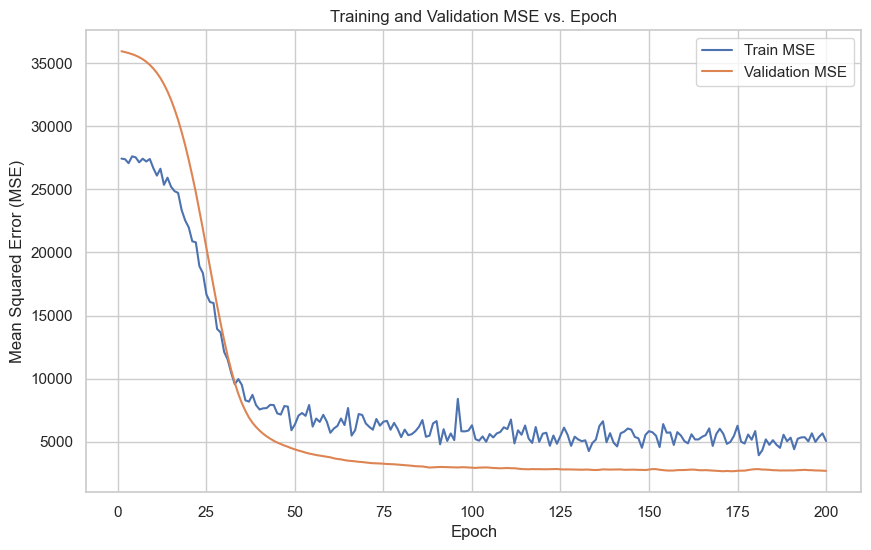

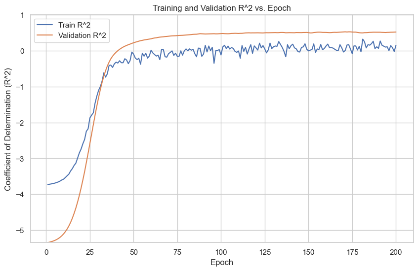

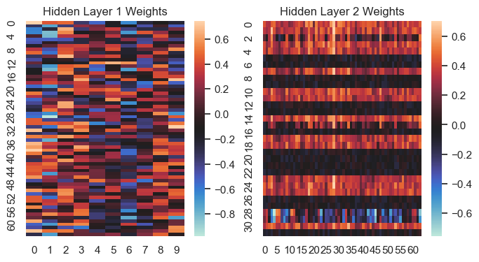

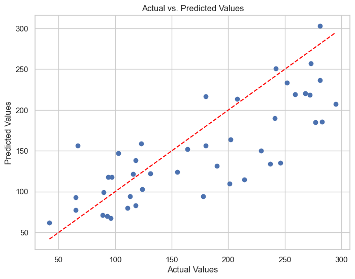

```python
hidden_layers = [64, 32]
acitvation_functions = [nn.ReLU, nn.ReLU, nn.ReLU, nn.Sigmoid] # should be two more for first and last layers
epochs = 200
learning_rate = 0.001
batch_size = 64
optimizer = optim.Adam
loss = nn.MSELoss()

# creating the model
trainer = NeuralNetworkTrainer(epochs, hidden_layers, acitvation_functions, learning_rate,
                               batch_size, optimizer, loss)

trainer.train(X_train, y_train, X_val, y_val)

# Understanding the model
epoch = trainer.suggested_epoch(10, 4) # MSE flutuates at most by 10 for 6 consecutive epochs
print(f"Suggested number of epochs is: {epoch}")
if epoch > 0:
    print(f"Validation MSE at this epoch: {trainer.val_losses[epoch]}")
    print(f"Validation R^2 at this epoch: {trainer.val_r2[epoch]}")
trainer.validation_mse_graph()
trainer.validation_r2_graph()
trainer.coefficient_heatmap()
trainer.actual_vs_predicted(X_val, y_val)
```

After tinkering with the above model, we can make informed selections for the model. Below, we compute the model again with the settled upon hyperparameters.

```
Epoch [1/117] - train dataset Loss: 28288.8797, train dataset R^2: -3.8491, test or validation dataset Loss: 33140.1328 test or validation dataset R^2: -4.5138
Epoch [2/117] - train dataset Loss: 27260.5622, train dataset R^2: -3.8491, test or validation dataset Loss: 33140.1328 test or validation dataset R^2: -4.5138
Epoch [3/117] - train dataset Loss: 29003.2107, train dataset R^2: -3.8491, test or validation dataset Loss: 33139.8594 test or validation dataset R^2: -4.5138
Epoch [4/117] - train dataset Loss: 28458.8965, train dataset R^2: -3.8489, test or validation dataset Loss: 33136.0703 test or validation dataset R^2: -4.5131
Epoch [5/117] - train dataset Loss: 28149.6752, train dataset R^2: -3.8468, test or validation dataset Loss: 33112.1250 test or validation dataset R^2: -4.5092
Epoch [6/117] - train dataset Loss: 28130.2330, train dataset R^2: -3.8395, test or validation dataset Loss: 33035.3164 test or validation dataset R^2: -4.4964
Epoch [7/117] - train dataset Loss: 28089.5862, train dataset R^2: -3.8244, test or validation dataset Loss: 32911.5508 test or validation dataset R^2: -4.4758
Epoch [8/117] - train dataset Loss: 27884.0070, train dataset R^2: -3.8020, test or validation dataset Loss: 32737.1426 test or validation dataset R^2: -4.4468
Epoch [9/117] - train dataset Loss: 27829.6791, train dataset R^2: -3.7716, test or validation dataset Loss: 32499.2363 test or validation dataset R^2: -4.4072
Epoch [10/117] - train dataset Loss: 27220.8214, train dataset R^2: -3.7343, test or validation dataset Loss: 32191.9023 test or validation dataset R^2: -4.3560
Epoch [11/117] - train dataset Loss: 28505.1657, train dataset R^2: -3.6793, test or validation dataset Loss: 31799.4082 test or validation dataset R^2: -4.2907
Epoch [12/117] - train dataset Loss: 27954.2291, train dataset R^2: -3.6195, test or validation dataset Loss: 31303.2188 test or validation dataset R^2: -4.2082
Epoch [13/117] - train dataset Loss: 25586.4029, train dataset R^2: -3.5385, test or validation dataset Loss: 30683.5605 test or validation dataset R^2: -4.1051
Epoch [14/117] - train dataset Loss: 26316.4741, train dataset R^2: -3.4499, test or validation dataset Loss: 29947.0840 test or validation dataset R^2: -3.9826
Epoch [15/117] - train dataset Loss: 25229.2838, train dataset R^2: -3.3230, test or validation dataset Loss: 29052.6387 test or validation dataset R^2: -3.8337
Epoch [16/117] - train dataset Loss: 24709.4408, train dataset R^2: -3.1954, test or validation dataset Loss: 28002.8203 test or validation dataset R^2: -3.6591
Epoch [17/117] - train dataset Loss: 22321.4086, train dataset R^2: -2.9948, test or validation dataset Loss: 26765.2324 test or validation dataset R^2: -3.4532
Epoch [18/117] - train dataset Loss: 22057.8516, train dataset R^2: -2.8108, test or validation dataset Loss: 25387.9395 test or validation dataset R^2: -3.2240
Epoch [19/117] - train dataset Loss: 20799.2383, train dataset R^2: -2.6581, test or validation dataset Loss: 23873.2188 test or validation dataset R^2: -2.9720
Epoch [20/117] - train dataset Loss: 19142.9630, train dataset R^2: -2.3860, test or validation dataset Loss: 22244.6562 test or validation dataset R^2: -2.7010
Epoch [21/117] - train dataset Loss: 18917.1046, train dataset R^2: -2.2128, test or validation dataset Loss: 20543.2969 test or validation dataset R^2: -2.4180
Epoch [22/117] - train dataset Loss: 17192.6214, train dataset R^2: -1.9555, test or validation dataset Loss: 18777.9297 test or validation dataset R^2: -2.1242
Epoch [23/117] - train dataset Loss: 14678.3414, train dataset R^2: -1.6367, test or validation dataset Loss: 16989.3203 test or validation dataset R^2: -1.8267
Epoch [24/117] - train dataset Loss: 13965.4270, train dataset R^2: -1.3867, test or validation dataset Loss: 15293.9668 test or validation dataset R^2: -1.5446
Epoch [25/117] - train dataset Loss: 14171.7698, train dataset R^2: -1.2559, test or validation dataset Loss: 13726.8984 test or validation dataset R^2: -1.2839
Epoch [26/117] - train dataset Loss: 10701.9064, train dataset R^2: -0.9571, test or validation dataset Loss: 12318.9609 test or validation dataset R^2: -1.0496
```

[output cut: 91 more lines]

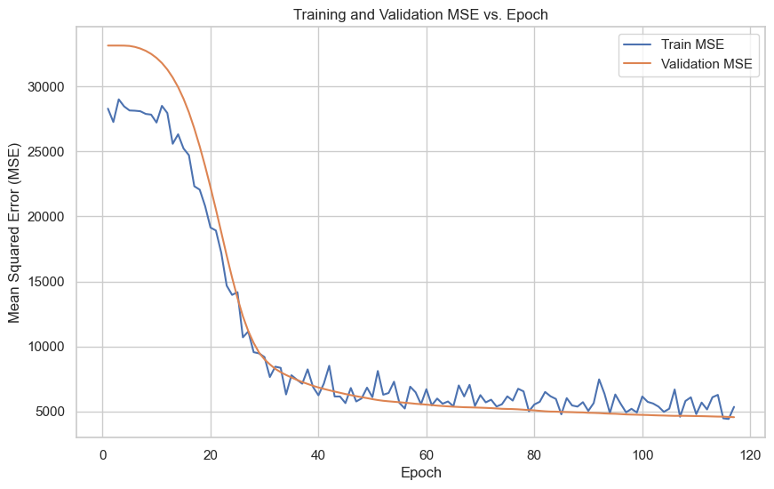

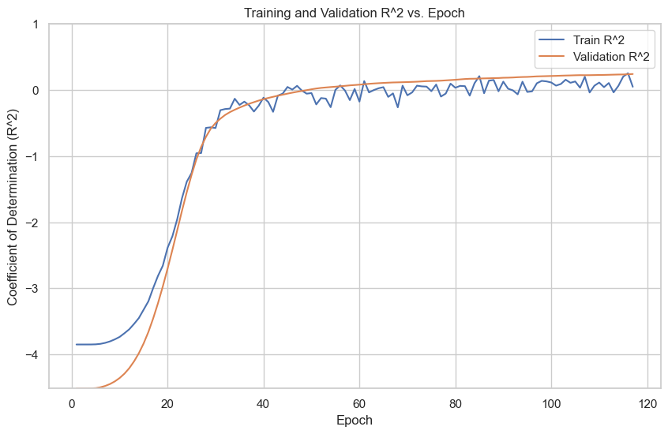

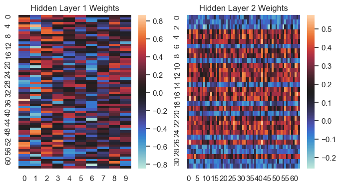

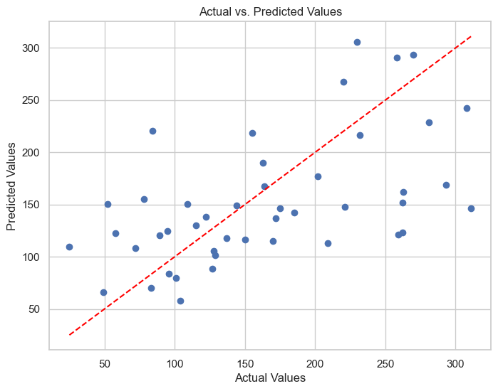

```python
epochs = epoch

# creating the model
trainer = NeuralNetworkTrainer(epochs, hidden_layers, acitvation_functions, learning_rate,
                               batch_size, optimizer, loss)

trainer.train(X_train_val, y_train_val, X_test, y_test, True)

# Understanding the model
trainer.validation_mse_graph()
trainer.validation_r2_graph()
trainer.coefficient_heatmap()
trainer.actual_vs_predicted(X_test, y_test)
```

We conclude by providing the metrics of the final model.

```python
# Make predictions on the test data
trainer.model.eval()
with torch.no_grad():
    y_pred = trainer.model(X_test).numpy().flatten()

# Calculate Mean Squared Error (MSE) for evaluation
mse = mean_squared_error(y_test, y_pred)
print(f"Mean Squared Error (MSE): {mse:.4f}")
r2 = r2_score(y_test, y_pred)
print(f"Coefficient of Determination (R^2): {r2:.4f}")
```

```
Mean Squared Error (MSE): 4559.8647
Coefficient of Determination (R^2): 0.2413
```